# 218188

*N* removed NAs: 7

*N* removed <18: 19

**Correct typo age:** 20

*N* total clean: 142

| Group | *N* | *M*<sub>age</sub> | % green |
| --- | --- | --- | --- |
| Control | 72 | 20.6 | 53.2 |
| Experim | 70 | 20.9 | 37.1 |

| Gender | *N* | *M*<sub>age</sub> | % green |
| --- | --- | --- | --- |
| Male | 79 | 20.8 | 45.1 |
| Female | 45 | 20.5 | 48.9 |
| Other | 18 | 21.2 | 37.0 |

**Main analysis results**

**car:**  
χ<sup>2</sup>(1) = 0, *p* = 1.000

**cleaner:**  
χ<sup>2</sup>(1) = 6.41, *p* = .011

**dishwasher:**  
χ<sup>2</sup>(1) = 9.64, *p* = .002

[interactive chart not shown]

[figure not shown]

[interactive chart not shown]

# 218188

Analysing Data, Spring 2020

# Methods

## Participants

*Table 1 Descriptive Statistics by Experimental Condition*

[output not shown]

## Design

This experiment is based on the study by Griskevicius, Tybur & Van den Bergh , Going Green to be Seen (2010). The hypothesis was that status motives will influence the choice of of environmentally-friendly, green products. To operationalise this hypothesis, participants were randomly allocated to one of two conditions : experimental or control. In the experimental condition, participants read a high-status story to elicit status motives whereas in the control condition, they read a status-neutral story. They were then asked to choose between a green and luxurious version of 3 types of products : a car, a dishwasher and a cleaner. Both the condition and category of product variables were factors with 2 levels : control vs experimental and luxury vs green respectively. It was predicted that people in the high-status condition would choose the green products over the luxurious version whereas participants in the control condition were more likely to choose the luxury product. Three chi-squared analyses were used to test this hypothesis, one for each product.

# Results

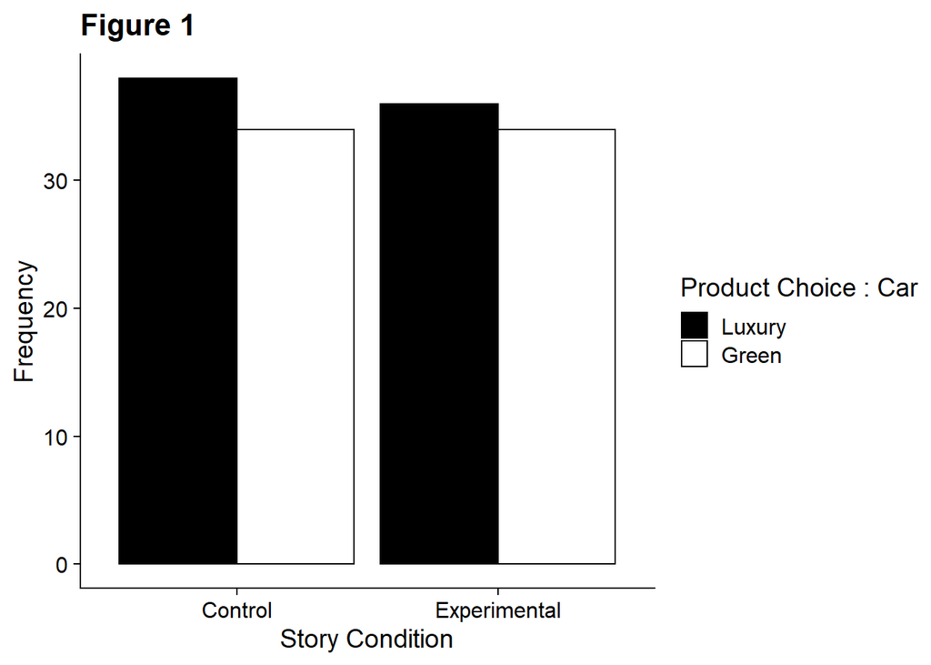

In Figures 2 & 3 we can see that in the control condition for the dishwasher and the cleaning product participants were more likely to choose the green product (33 versus 39 and 30 versus 42 respectively).

[figure not shown]

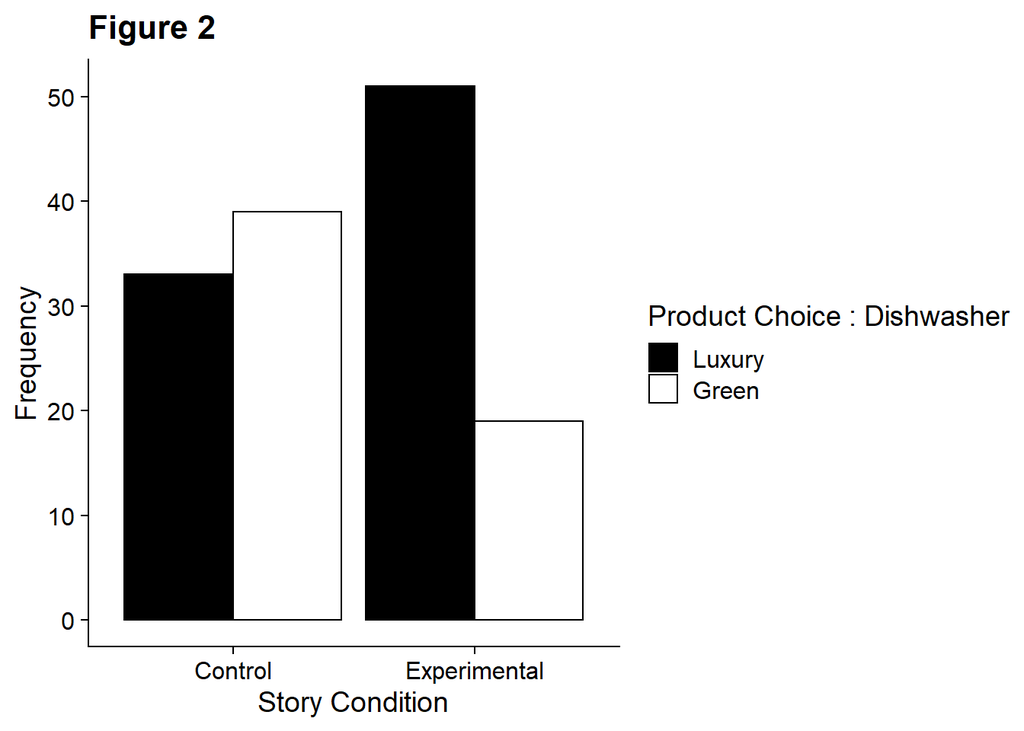

# Discussion

In summary, we predicted that activating status motives would lead participants to choose the green, environmentally friendly product over the luxurious one as it could signal one’s prosocial nature. However, in the case of the dishwasher and cleaning product, eliciting status motives actually had the opposite effect; participants were significantly more likely to choose the luxury version of the two products after reading a story that elicited status motives. When participants were asked to choose between a green, environmentally-friendly or luxury car there was no significant effect of status motives. Both before and after activating status motives, participants were more likely to choose the luxury version which could be due to nice cars being a typical display of one’s wealth.

Implications and future research :

These results differ significantly from the original study by Grisckevicius et al (2010) in which they found that activating status motives led participants to choose the green product in favour of the luxury version for all products. This could be due to differences in the sample population. For instance, the sample in Griskevicius et al may include people that are naturally more concerned for the environment, maybe coming from rural areas whereas the sample in this study may include participants from urban areas, that are much more luxury-orientated. Future research could therefore benefit from comparing specific population samples in terms of age, socioeconomic status and cultural background variables. An interesting aspect to also consider in future research is the reason behind people engaging in prosocial versus antisocial behaviour in regards to status. Anderson, C., Hildreth, J. A. D., & Howland, L. (2015) reviewed studies that showed that on one hand, status motives can elicit hard work, prosocial, generous behaviour however, it can also have the reverse effect and cause people to be antisocial, engage in conspicuous consumption and aggressive behaviour. Our results support this second finding whereby upon eliciting status motives, participants were more likely to engage in conspicuous consumption. It is important to understand the reason behind these two contrasting behaviours in order to find a way to get people to engage in more pro-environmental actions.

Strengths & limitations :

This study has some limitations. For instance, the high status motive primes are not necessarily appropriate for societies that are a lot more community-based as well as for people from lower socioeconomic status who may find it difficult to imagine the scenario described in the status story. This could be an issue when trying to generalise the study to the population and should therefore be adapted to suit all cultures and social classes. Another limitation is regarding the sample of participants. Indeed, all participants were of a very similar age which poses a problem for ecological validity as it is not representative of the whole population. Future research should therefore include participants of all ages and adjust the high status stories to suit all backgrounds.

Conclusion :

In conclusion, based on the results of this study, status motives do not lead people to be more prosocial and in fact lead to conspicuous consumption. The desire for status, it seems, is not enough to make people engage in prosocial, altruistic behaviour. It is important to test this experiment on more samples in order to get a broad understanding of what may contribute to people engaging in prosoial versus antisocial behaviour and in turn find ways of encouraging people to be more environmentally orientated.

# References

Griskevicius, V., Tybur, J. M., & Van den Berigh, B.(2010). Going green to be seen: status, repuation, and conspicuous conservation. *Journal of Personality and Social Psychology, 98*(3), 392.

Anderson, C., Hildreth, J. A. D., & Howland, L. (2015). Is the desire for status a fundamental human motive ? A review of empirical literature. *Psychological Bulletin, 141*(3), 574.